# Scraping Text

Marketing Analytics

Berry-Cherian Experience

### Table of Contents

Last time, we played around with scraping tables:

```r
library(rvest)

library(magrittr)

cpiTable = read_html("https://www.usinflationcalculator.com/inflation/consumer-price-index-and-annual-percent-changes-from-1913-to-2008/") %>%
  html_table() %>%
  magrittr::extract2(1) # or `[[`(1)
```

As helpful as getting tables might be, there will be other bits of data that we might want to be able to pull. For example, we might want to keep track of who is sitting on a [Board of Directors](https://www.apple.com/leadership/). That is clearly not a table, so how do we get at it?

After inspecting the elements of the names and roles, we should have a pretty good idea about the *nodes* that we are trying to pull.

```r
appleBoard = data.frame(name = read_html("https://www.apple.com/leadership/") %>%
                          html_nodes(".typography-body.block-link.profile-name") %>%
                          html_text(),
                        role = read_html("https://www.apple.com/leadership/") %>%
                          html_nodes(".typography-body.typography-profile-title") %>%
                          html_text(),
                        stringsAsFactors = FALSE)

knitr::kable(appleBoard)
```

| name | role |
| --- | --- |
| Tim Cook | CEO |
| Katherine Adams | Senior Vice President andGeneral Counsel |
| Angela Ahrendts | Senior Vice PresidentRetail |
| Eddy Cue | Senior Vice PresidentInternet Software and Services |
| Craig Federighi | Senior Vice PresidentSoftware Engineering |
| John Giannandrea | Senior Vice PresidentMachine Learning and AI Strategy |
| Jonathan Ive | Chief Design Officer |
| Luca Maestri | Senior Vice President andChief Financial Officer |
| Dan Riccio | Senior Vice PresidentHardware Engineering |
| Philip W. Schiller | Senior Vice PresidentWorldwide Marketing |
| Johny Srouji | Senior Vice PresidentHardware Technologies |
| Jeff Williams | Chief Operating Officer |
| Steve Dowling | Vice PresidentCommunications |
| Lisa Jackson | Vice President Environment,Policy and Social Initiatives |
| Isabel Ge Mahe | Vice President and Managing Director of Greater China |
| Tor Myhren | Vice PresidentMarketing Communications |
| Deirdre O’Brien | Vice PresidentPeople |

That is a pretty simple example of finding some text and pulling it in as data.

## Packages

The following packages will be extremely useful to us:

```r
library(dplyr)

library(ggplot2)

library(magrittr) # maybe

library(rvest)

library(stringr)
```

## Scraping Text

Yelp will be a good place to start scraping some data, and for a few reasons: it is well structured, there is a nice chunk of data to be gotten, and it is rich with text. Furthermore, it will be a good starting point for our sentiment analysis next time.

### Evil Czech

```r
evilCzech = "https://www.yelp.com/biz/evil-czech-brewery-and-public-house-mishawaka"

evilCzechHTML = read_html(evilCzech) # This pulls the entire html tree

ecRatings = evilCzechHTML %>%
  html_nodes(".review-wrapper .review-content .i-stars") %>% # Grabbing specific nodes
  html_attr("title") %>% # Getting the title attribute from the nodes
  stringr::str_extract("[0-5]") # Just keeping the number within the rating

ecReviews = evilCzechHTML %>%
  html_nodes(".review-wrapper .review-content p") %>%
  html_text()

evilCzechData = data.frame(ratings = ecRatings,
                           reviews = ecReviews,
                           restaurant = "evil czech",
                           stringsAsFactors = FALSE)
```

### Fiddler’s Hearth

```r
fiddlers = "https://www.yelp.com/biz/fiddlers-hearth-south-bend"

fiddlersHTML = read_html(fiddlers)

fhRatings = fiddlersHTML %>%
  html_nodes(".review-wrapper .review-content .i-stars") %>%
  html_attr("title") %>%
  stringr::str_extract("[0-5]")

fhReviews = fiddlersHTML %>%
  html_nodes(".review-wrapper .review-content p") %>%
  html_text()

fhData = data.frame(ratings = fhRatings,
                    reviews = fhReviews,
                    restaurant = "fiddlers hearth",
                    stringsAsFactors = FALSE)
```

### Crooked Ewe

```r
crookedEwe = "https://www.yelp.com/biz/crooked-ewe-brewery-and-ale-house-south-bend"

crookedEweHTML = read_html(crookedEwe)

ceRatings = crookedEweHTML %>%
  html_nodes(".review-wrapper .review-content .i-stars") %>%
  html_attr("title") %>%
  stringr::str_extract("[0-5]")

ceReviews = crookedEweHTML %>%
  html_nodes(".review-wrapper .review-content p") %>%
  html_text()

ceData = data.frame(ratings = ceRatings,
                    reviews = ceReviews,
                    restaurant = "crooked ewe",
                    stringsAsFactors = FALSE)
```

### Cambodian Thai

```r
cambodianThai = "https://www.yelp.com/biz/cambodian-thai-south-bend"

cambodianThaiHTML = read_html(cambodianThai)

ctRatings = cambodianThaiHTML %>%
  html_nodes(".review-wrapper .review-content .i-stars") %>%
  html_attr("title") %>%
  stringr::str_extract("[0-5]")

ctReviews = cambodianThaiHTML %>%
  html_nodes(".review-wrapper .review-content p") %>%
  html_text()

ctData = data.frame(ratings = ctRatings,
                    reviews = ctReviews,
                    restaurant = "cambodian thai",
                    stringsAsFactors = FALSE)
```

### Corndance Tavern

```r
corndance = "https://www.yelp.com/biz/corndance-tavern-mishawaka"

corndanceHTML = read_html(corndance)

cdRatings = corndanceHTML %>%
  html_nodes(".review-wrapper .review-content .i-stars") %>%
  html_attr("title") %>%
  stringr::str_extract("[0-5]")

cdReviews = corndanceHTML %>%
  html_nodes(".review-wrapper .review-content p") %>%
  html_text()

cdData = data.frame(ratings = cdRatings,
                    reviews = cdReviews,
                    restaurant = "corndance tavern",
                    stringsAsFactors = FALSE)
```

At the end, we did a lot of copy and paste action there. Once you are down your R path a little bit more, you might find yourself writing functions to handle the heavy lifting and minimizing your copy and paste time.

### Combining Data

After running all of the previous code, we have 5 distinct data frames. We need to combine them into one:

```r
allReviews = dplyr::bind_rows(cdData, ceData, ctData, evilCzechData, fhData)
```

Now would be a really good place to make note about the different variable types that you might encounter when scraping data (and data types in R generally).

If we try to do something reasonable like taking the mean rating, we might see some issue:

```r
mean(allReviews$ratings)
```

[output not shown]

Why did this happen? Looking at the data structure will help us:

```r
str(allReviews)
```

```
'data.frame':   100 obs. of  3 variables:
 $ ratings   : chr  "5" "4" "4" "3" ...
 $ reviews   : chr  "Came here on my birthday with my family, it was suggested by my cousin as one of the best places to have a good"| __truncated__ "I've been here once and I was rather impressed. The bison or buffalo bites (can't remember) were different from"| __truncated__ "After coming back a f…
 $ restaurant: chr  "corndance tavern" "corndance tavern" "corndance tavern" "corndance tavern" ...
```

Our rating variable really is not a number – it is a character.

Let’s change our ratings to numbers and try something a little bit different (we will count the number of words in each review). We will use the `mutate` function to add new variables to our data:

```r
allReviews = allReviews %>%
  dplyr::mutate(ratings = as.numeric(ratings),
                wordCount = stringr::str_count(reviews, pattern = "\\S+"))
```

Let’s try to get our mean again:

```r
mean(allReviews$ratings)
```

```
[1] 4.13
```

You should try to get the mean for number of words!

When scraping data, you always need to consider what the data looks like when you get it in. For the sake of demonstration, let’s go back to an individual restaurant:

```r
ecStars = evilCzechHTML %>%
  html_nodes(".review-wrapper .review-content .i-stars") %>%
  html_attr("title")

ecStars
```

```
 [1] "5.0 star rating" "1.0 star rating" "4.0 star rating"
 [4] "4.0 star rating" "5.0 star rating" "4.0 star rating"
 [7] "3.0 star rating" "5.0 star rating" "2.0 star rating"
[10] "4.0 star rating" "4.0 star rating" "5.0 star rating"
[13] "1.0 star rating" "5.0 star rating" "5.0 star rating"
[16] "5.0 star rating" "5.0 star rating" "5.0 star rating"
[19] "5.0 star rating" "5.0 star rating"
```

We see that we would likely need to do a little cleaning on these values. We already saw one way to do it with `str_extract()`, but here is a slightly different way:

```r
stringr::str_replace_all(ecStars, pattern = " star rating", replacement = "")
```

```
 [1] "5.0" "1.0" "4.0" "4.0" "5.0" "4.0" "3.0" "5.0" "2.0" "4.0" "4.0"
[12] "5.0" "1.0" "5.0" "5.0" "5.0" "5.0" "5.0" "5.0" "5.0"
```

This is particularly useful when a table (or text) has dollar signs!

Now, we can check on some visuals from our data:

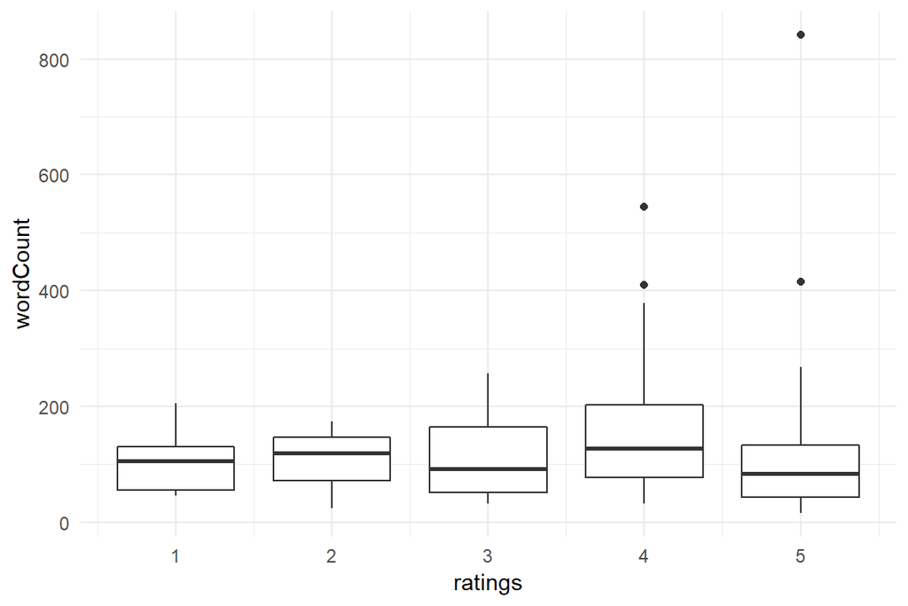

```r
ggplot(allReviews, aes(x = ratings, y = wordCount, group = ratings)) +
  geom_boxplot() +
  theme_minimal()
```

This is slightly following an inverted U (tenuously, at best), which I would expect. Let’s not forget that we have a natural grouping variable in restaurant. There are countless ways to look at this in R:

Here are boxplots broken out into small multiples by restaurant:

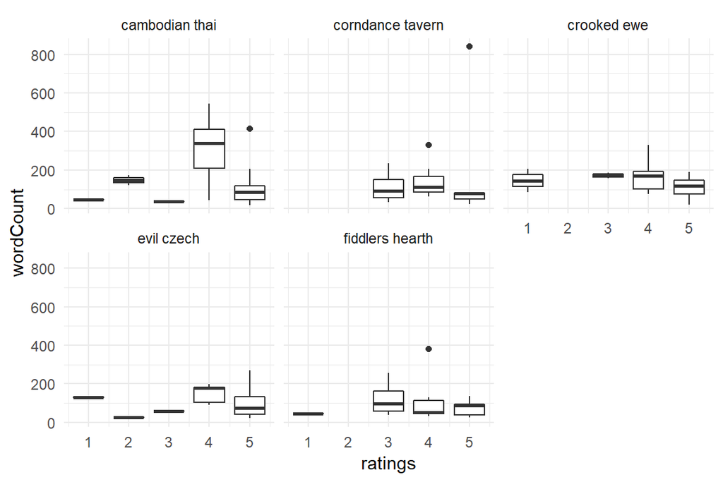

```r
ggplot(allReviews, aes(ratings, wordCount, group = ratings)) +
  geom_boxplot() +
  facet_wrap(~ restaurant) +
  theme_minimal()
```

Or we can scrap the boxplot and use scatterplots:

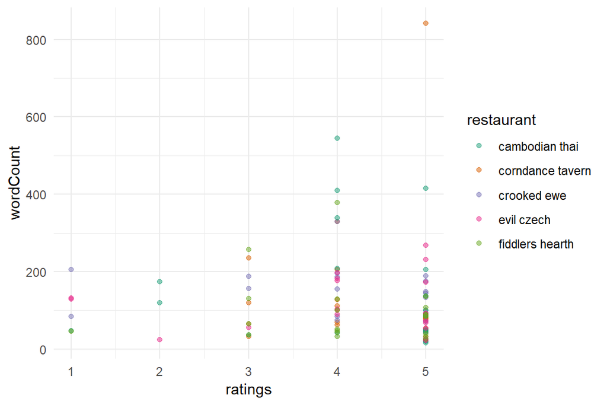

```r
library(gganimate)

ggplot(allReviews, aes(ratings, wordCount, color = restaurant)) +
  geom_point(alpha = .5) +
  scale_color_brewer(type = "qual", palette = "Dark2") +
  theme_minimal()
```

And with just a little more effort, we can animate that plot:

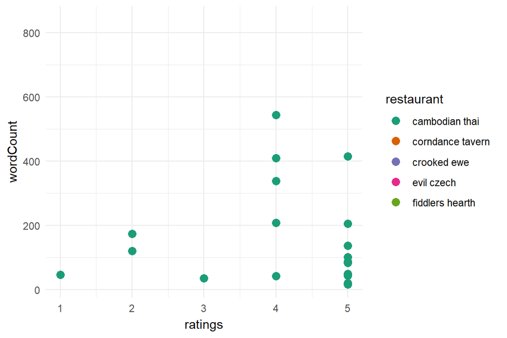

```r
library(gganimate)

ggplot(allReviews, aes(ratings, wordCount)) +
  geom_point(aes(group = restaurant, color = restaurant), size = 3) +
  scale_color_brewer(type = "qual", palette = "Dark2") +
  transition_states(restaurant, transition_length = 5, state_length = 2) +
  enter_fade() +
  exit_shrink() +
  theme_minimal()
```

We could also turn it into a fully interactive visualization:

```r
library(plotly)

scatterTest = ggplot(allReviews, aes(ratings, wordCount)) +
  geom_point(aes(group = restaurant, color = restaurant), size = 3) +
  scale_color_brewer(type = "qual", palette = "Dark2") +
  theme_minimal()

ggplotly(scatterTest)
```

[interactive chart not shown]

Finally, we might want to play with a model:

```r
ratingsMod = lm(ratings ~ wordCount, data = allReviews)

summary(ratingsMod)
```

```
Call:
lm(formula = ratings ~ wordCount, data = allReviews)

Residuals:
     Min       1Q   Median       3Q      Max
-3.14332 -0.14268 -0.07357  0.86258  0.98535

Coefficients:
              Estimate Std. Error t value Pr(>|t|)
(Intercept)  4.1507683  0.1649479  25.164   <2e-16 ***
wordCount   -0.0001618  0.0009360  -0.173    0.863
---
Signif. codes:  0 '***' 0.001 '**' 0.01 '*' 0.05 '.' 0.1 ' ' 1

Residual standard error: 1.131 on 98 degrees of freedom
Multiple R-squared:  0.000305,  Adjusted R-squared:  -0.009896
F-statistic: 0.0299 on 1 and 98 DF,  p-value: 0.8631
```

Remember when we counted the words within a review? You should try to do that with exclamation marks and see what that looks like in a model!

This is just a brief dip into scraping text from the web. It is something that takes a fair amount of practice for doing it in a “production” manner, but you can quickly grab some interesting stuff without too much hassle.